# SIBER

Arturo Bell Enríquez García

## Libraries

```r
library(SIBER)
library(ggplot2)
library(ggExtra)
library(ggConvexHull)
library(HDInterval)
library(mcmcplots)
library(ggmcmc)
library(coda)
library(lattice)
library(MCMCvis)
library(bayesplot)
```

## Data loading

```r
data <- read.table("glm.csv", sep = ",", header = T)
colnames(data)[8:9] <- c("iso1", "iso2")
head(data)
```

|  | sp | code | year | temporada | sexo | estadio | r_edad | iso1 | iso2 | tp |
| --- | --- | --- | --- | --- | --- | --- | --- | --- | --- | --- |
| 1 | H.dipterurus | 2 | 2015 | Calida | M | Juvenil | 1 | 16.30122 | -14.50678 | 3.318719 |
| 2 | H.dipterurus | 51 | 2015 | Calida | H | Juvenil | 1 | 16.83237 | -17.81040 | 3.489509 |
| 3 | H.dipterurus | 15 | 2015 | Calida | M | Adulto | 3 | 17.13546 | -15.83143 | 3.586966 |
| 4 | H.dipterurus | 6 | 2015 | Calida | H | Juvenil | 1 | 13.12309 | -15.96596 | 2.296815 |
| 5 | H.dipterurus | 4 | 2015 | Calida | M | Adulto | 2 | 17.63312 | -16.71944 | 3.746983 |
| 6 | H.dipterurus | 11 | 2015 | Calida | H | Juvenil | NA | 17.59479 | -16.89169 | 3.734659 |

## “Global” SIBER:

### Dataset arrangement

```r
global <- subset(data, select = c(sp, iso1, iso2))
global$group <- factor(global$sp, labels = c(1:3))
global$community <- 1
global
```

|  | sp | iso1 | iso2 | group | community |
| --- | --- | --- | --- | --- | --- |
| 1 | H.dipterurus | 16.30122 | -14.506785 | 1 | 1 |
| 2 | H.dipterurus | 16.83237 | -17.810405 | 1 | 1 |
| 3 | H.dipterurus | 17.13546 | -15.831434 | 1 | 1 |
| 4 | H.dipterurus | 13.12309 | -15.965960 | 1 | 1 |
| 5 | H.dipterurus | 17.63312 | -16.719438 | 1 | 1 |
| 6 | H.dipterurus | 17.59479 | -16.891687 | 1 | 1 |
| 7 | H.dipterurus | 17.38576 | -17.775261 | 1 | 1 |
| 8 | H.dipterurus | 17.53165 | -16.483062 | 1 | 1 |
| 9 | H.dipterurus | 17.36609 | -14.911497 | 1 | 1 |
| 10 | H.dipterurus | 17.15074 | -16.719575 | 1 | 1 |

[output cut: 214 more lines]

### Basic plot

Parameters and basic information

```r
global_colors <- c('#1f77b4', '#ff7f0e', '#2ca02c')
xlims <- c(min(global$iso2)-0.5, max(global$iso2)+0.5)
ylims <- c(min(global$iso1)-0.5, max(global$iso1)+0.5)
species <- unique(global$sp)
```

Plot

```r
glob_ellipses <- ggplot(data = global, aes(x = iso2, y = iso1, color = as.factor(group))) +
                 geom_point() +
                 stat_ellipse(level = 0.4) +
                 geom_convexhull(fill = NA, linetype = "dashed", alpha = 0.05) +
                 scale_color_manual(values = global_colors, name = "Species", labels = species) +
                 scale_x_continuous(limits = xlims, breaks = c(seq(-18, -8, 2))) +
                 scale_y_continuous(limits = ylims, breaks = c(seq(10, 20, 2))) +
                 labs(title = element_blank(),
                      x = expression({delta}^13*C~'(\u2030)'),
                      y = expression({delta}^15*N~'(\u2030)')) +
                 theme_bw() +
                 theme(aspect.ratio = 1,
                       panel.grid.major = element_blank(),
                       panel.grid.minor = element_blank(),
                       legend.position = c(0.15, 0.1),
                       legend.background = element_blank())

#cairo_pdf("global_ellipses.pdf", family = "Times", height = 6, width = 6)
#glob_ellipses
#dev.off()
```

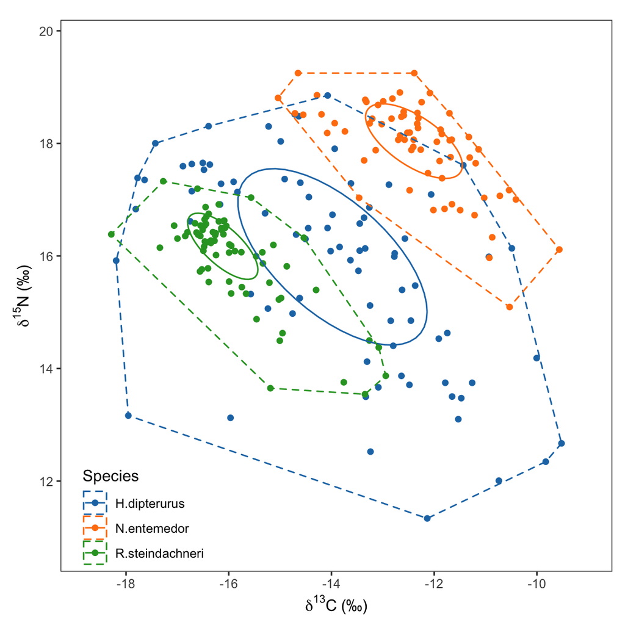

```r
glob_ellipses
```

### Fitting the Bayesian Bi-variate Normal models:

Creation of the SIBER object:

```r
siber_glob <- createSiberObject(global[,2:5])
```

Parameters of the MCMC:

```r
parms <- list()
parms$n.iter   <- 2000
parms$n.burnin <- 25000
parms$n.thin   <- 1
parms$n.chains <- 3
parms$save.output <- TRUE
parms$save.dir <- paste(getwd(),"/global", sep = "")
```

Prior distributions:

```r
priors <- list()
priors$R <- 1 * diag(2)
priors$k <- 2
priors$tau.mu <- 1.0E-3
```

Sampling of the posterior distributions:

```r
ellipses.posterior <- siberMVN(siber_glob, parms, priors)
```

#### Diagnostics:

Cycling through every model to extract information:

```r
all_files <- dir(parms$save.dir, full.names = T)
model_files <- all_files[grep("jags_output", all_files)]

model_summary <- list()

for (i in seq_along(model_files)) {
  load(model_files[i])

  mcmc_list <- coda::as.mcmc(do.call("cbind", output))

  model_summary[[i]] <- MCMCsummary(output,
                                    params = "all",
                                    probs = c(0.025, 0.975),
                                    round = 3)
  MCMCtrace(output,
            params = "all",
            iter = parms$n.iter,
            Rhat = T,
            n.eff = T,
            ind = T,
            type = "density",
            open_pdf = F,
            filename = sprintf("MCMCtrace_%d", i))
}
```

Autocorrelation plots:

```r
cairo_pdf("global_autocorr.pdf", family = "Times", height = 10, width = 12)
gridExtra::grid.arrange(mcmc_acf(ellipses.posterior[1]) + labs(title = species[1]),
                        mcmc_acf(ellipses.posterior[2]) + labs(title = species[2]),
                        mcmc_acf(ellipses.posterior[3]) + labs(title = species[3]),
                        nrow = 3)
dev.off()
```

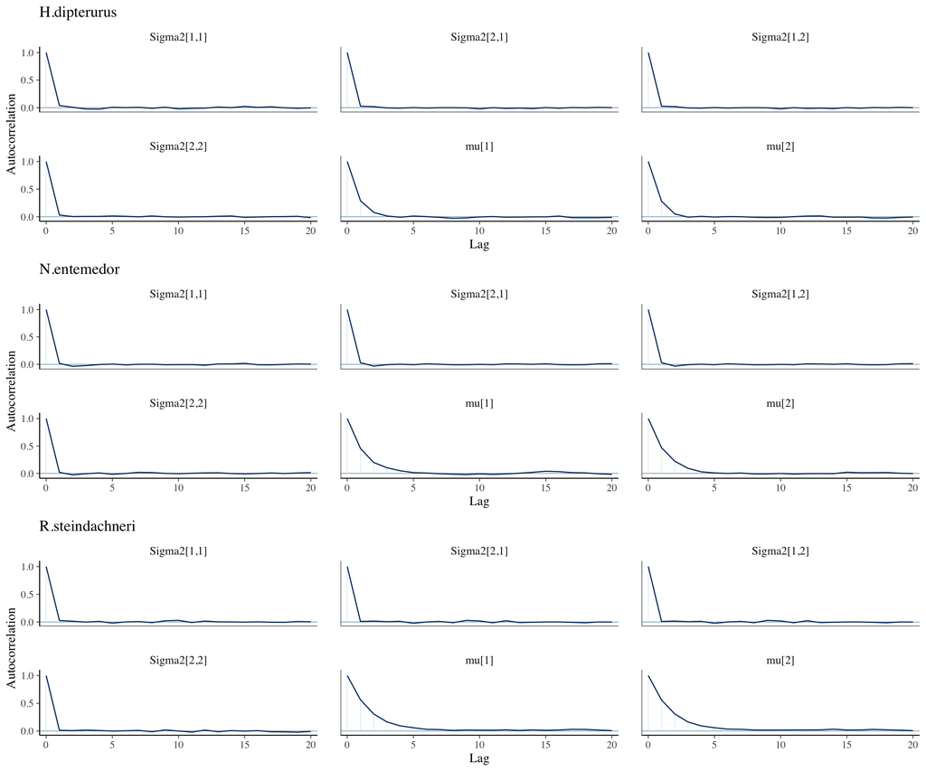

```r
gridExtra::grid.arrange(mcmc_acf(ellipses.posterior[1]) + labs(title = species[1]),
                        mcmc_acf(ellipses.posterior[2]) + labs(title = species[2]),
                        mcmc_acf(ellipses.posterior[3]) + labs(title = species[3]),
                        nrow = 3)
```

```r
for (i in seq_along(model_files)) {
  load(model_files[i])
  print(species[i])
  print(model_summary[[i]])
}
```

```
## [1] "H.dipterurus"
##               mean    sd   2.5%  97.5% Rhat n.eff
## Sigma2[1,1]  1.027 0.165  0.752  1.406    1  5721
## Sigma2[2,1] -0.558 0.134 -0.858 -0.333    1  5487
## Sigma2[1,2] -0.558 0.134 -0.858 -0.333    1  5487
## Sigma2[2,2]  1.028 0.167  0.748  1.399    1  5742
## mu[1]        0.002 0.112 -0.217  0.222    1  3347
## mu[2]       -0.003 0.113 -0.224  0.214    1  3507
## [1] "N.entemedor"
##               mean    sd   2.5%  97.5% Rhat n.eff
## Sigma2[1,1]  1.031 0.181  0.727  1.437    1  6387
## Sigma2[2,1] -0.683 0.151 -1.023 -0.432    1  6319
## Sigma2[1,2] -0.683 0.151 -1.023 -0.432    1  6319
## Sigma2[2,2]  1.029 0.182  0.736  1.440    1  6330
## mu[1]        0.000 0.122 -0.230  0.246    1  2315
## mu[2]        0.000 0.121 -0.246  0.234    1  2183
## [1] "R.steindachneri"
##               mean    sd   2.5%  97.5% Rhat n.eff
## Sigma2[1,1]  1.027 0.173  0.744  1.413    1  5668
## Sigma2[2,1] -0.770 0.152 -1.108 -0.522    1  6000
## Sigma2[1,2] -0.770 0.152 -1.108 -0.522    1  6000
## Sigma2[2,2]  1.025 0.173  0.736  1.405    1  5848
## mu[1]        0.000 0.119 -0.237  0.235    1  1731
## mu[2]        0.001 0.119 -0.234  0.231    1  1702
```

#### Inferences

Generation of the ellipses:

```r
sea_b <- siberEllipses(ellipses.posterior)
summary(sea_b)
```

```
##        V1               V2              V3
##  Min.   : 6.508   Min.   :1.386   Min.   :1.038
##  1st Qu.: 8.887   1st Qu.:1.966   1st Qu.:1.540
##  Median : 9.588   Median :2.138   Median :1.668
##  Mean   : 9.660   Mean   :2.156   Mean   :1.681
##  3rd Qu.:10.353   3rd Qu.:2.320   3rd Qu.:1.803
##  Max.   :14.541   Max.   :3.396   Max.   :2.556
```

Graphical comparisons. First, transform the object to a data.frame and melt it to long format:

```r
sea_bt <- reshape2::melt(as.data.frame(sea_b))
colnames(sea_bt) <- c("sp", "SEAb")
head(sea_bt)
```

|  | sp | SEAb |
| --- | --- | --- |
| 1 | V1 | 9.486188 |
| 2 | V1 | 8.906732 |
| 3 | V1 | 9.139347 |
| 4 | V1 | 8.638986 |
| 5 | V1 | 9.626251 |
| 6 | V1 | 9.246288 |

Get the HDI for each species:

```r
hdi <- as.data.frame(t(apply(sea_b, 2, FUN = HDInterval::hdi)))
hdi <- cbind(hdi, means = t(as.data.frame(t(apply(sea_b, 2, FUN = mean)))))
hdi["sp"] <- row.names(hdi)
hdi
```

|  | lower | upper | means | sp |
| --- | --- | --- | --- | --- |
| V1 | 7.547215 | 11.836912 | 9.659745 | V1 |
| V2 | 1.650020 | 2.660345 | 2.155948 | V2 |
| V3 | 1.313072 | 2.083308 | 1.681112 | V3 |

Violin plot with the posterior distributions of the SEAb:

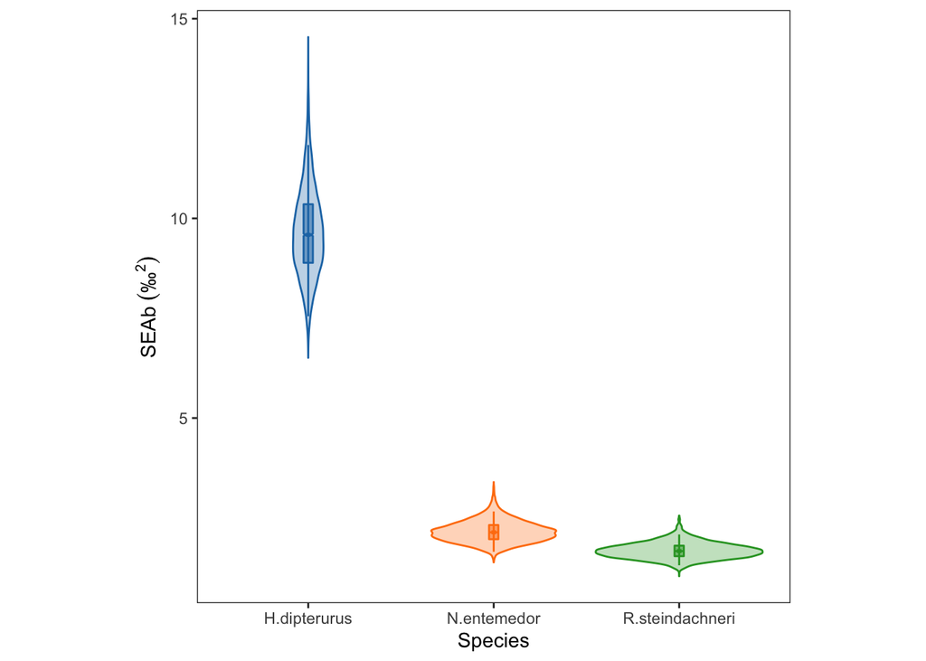

```r
seab_global <- ggplot() +
               geom_violin(data = sea_bt, aes(x = sp, y = SEAb, fill = sp, color = sp),
                           show.legend = F, alpha = 0.3) +
               geom_boxplot(data = sea_bt,
                            aes(x = sp, y = SEAb, fill = sp, color = sp),
                            alpha = 0.5, width = 0.05, notch = T, show.legend = F,
                            outlier.shape = NA, coef = 0) +
               scale_fill_manual(values = global_colors) +
               scale_color_manual(values = global_colors) +
               geom_linerange(data = hdi,
                              aes(x = sp, ymin = lower, ymax = upper, color = sp),
                              show.legend = F) +
               theme_bw()+
               theme(aspect.ratio = 1,
                     panel.grid.major = element_blank(),
                     panel.grid.minor = element_blank(),
                     legend.position = c(0.2, 0.15),
                     legend.background = element_blank()) +
               labs(x = "Species",
                    y = expression("SEAb " ('\u2030' ^2) )) +
               scale_x_discrete(labels = species)
#cairo_pdf("global_seab.pdf", family = "Times", height = 5, width = 5)
seab_global
```

```r
#dev.off()
```

Posterior Differences:

```r
# Define the comparisons
comps <- expand.grid(a = unique(as.integer(global$group)), b = unique(as.integer(global$group)))
comps <- comps[(comps$a != comps$b & comps$b > comps$a), ]
comps <- comps[order(comps$a),]

# Put the results in different objects:
diffs <- data.frame()
diff_glob <- data.frame()
p_sup <- data.frame()
for (i in seq_along(comps$a)) {
  a <- comps$a[i]
  b <- comps$b[i]
  comp <- paste(species[a], "-", species[b])
  diff <- sea_b[, a] - sea_b[, b]
  sup <- subset(diff, diff>0, select = diff)

  diffs <- rbind(diffs,
                 data.frame(comp = comp,
                            diff = diff))
  diff_glob <- rbind(diff_glob,
                     data.frame(comp = comp,
                                mean = mean(diff),
                                IQr = t(HDInterval::hdi(diff, credMass = 0.5)),
                                hdi = t(HDInterval::hdi(diff, credMass = 0.95))
                                )
                     )
  p_sup <- rbind(p_sup,
                 data.frame(comp = comp,
                            p_sup = (length(sup)/length(diff))*100))
}

diff_glob$comp <- factor(diff_glob$comp, ordered = T)
```

HDIs of differences

```r
diff_glob
```

| comp | mean | IQr.lower | IQr.upper | hdi.lower | hdi.upper |
| --- | --- | --- | --- | --- | --- |
| H.dipterurus - N.entemedor | 7.5037975 | 6.6230932 | 8.1095054 | 5.2482090 | 9.648069 |
| H.dipterurus - R.steindachneri | 7.9786336 | 7.1479967 | 8.6240669 | 5.8936604 | 10.239606 |
| N.entemedor - R.steindachneri | 0.4748361 | 0.2723955 | 0.7130259 | -0.1668761 | 1.131790 |

Probabilities of differences:

```r
p_sup
```

| comp | p_sup |
| --- | --- |
| H.dipterurus - N.entemedor | 100.00 |
| H.dipterurus - R.steindachneri | 100.00 |
| N.entemedor - R.steindachneri | 92.95 |

Forestplot of the $HDI_{95\%}$ of the differences

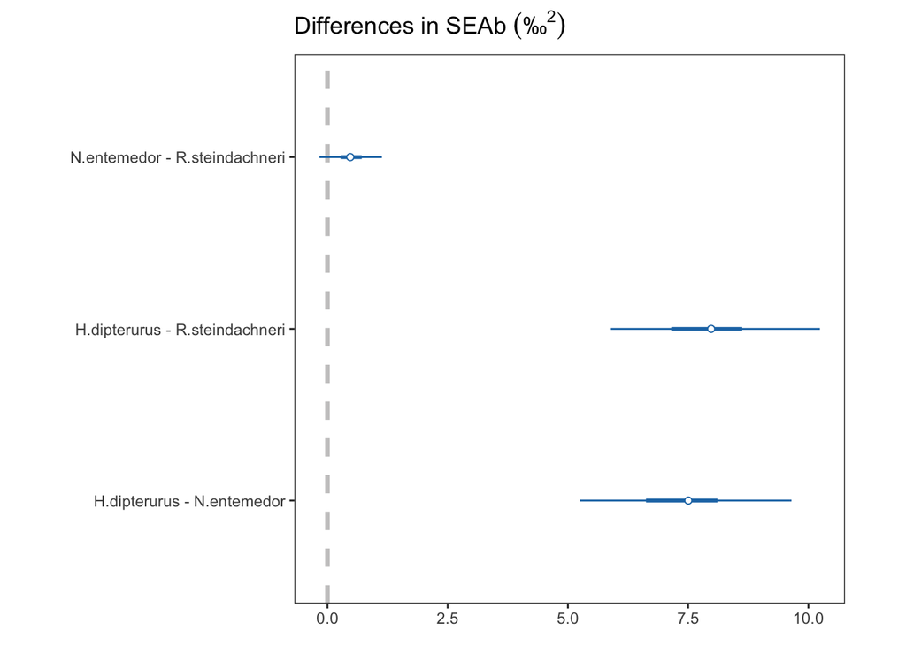

```r
global_forest <- ggplot(data = diff_glob) +
                 geom_vline(xintercept = 0, linetype = "dashed", color = "#C9C8C8", size = 1.2) +
                 geom_linerange(aes(y = comp, xmin = IQr.lower, xmax = IQr.upper),
                                color = global_colors[1], size = 1) +
                 geom_linerange(aes(y = comp, xmin = hdi.lower, xmax = hdi.upper),
                                color = global_colors[1]) +
                 geom_point(aes(x = mean, y = comp), color = global_colors[1], fill = "white", size = 1.5, shape = 21) +
                 theme_bw() +
                 theme(aspect.ratio = 1,
                       panel.grid.major = element_blank(),
                       panel.grid.minor = element_blank(),
                       legend.position = c(0.2, 0.15),
                       legend.background = element_blank()) +
                 labs(title = expression("Differences in SEAb " ('\u2030' ^2) ),
                      x = element_blank(),
                      y = element_blank())
#cairo_pdf("global_forest.pdf", family = "Times", height = 5, width = 5)
global_forest
```

```r
#dev.off()
```

#### Eccentricity and theta

Eccentricities represent the elongation of the ellipse, that is, how far they are from a perfect circle (0 eccentricity). Lower values indicate a rounder ellipse, while higher values indicate a more elongated ellipse.

```r
mat_ecc <- function(x) {
  mat <- matrix(x, 2, 2)
  ecc <- sigmaSEA(mat)$ecc
  return(ecc)
}

mat_theta <- function(x){
  mat <- matrix(x, 2, 2)
  theta <- sigmaSEA(mat)$theta
  return(theta)
}

ecc <- data.frame()
for (sp in seq_along(ellipses.posterior)) {
  ecc <- rbind(ecc,
               data.frame(sp = species[sp],
                          ecc = apply(ellipses.posterior[[sp]][,1:4], 1, mat_ecc),
                          theta = apply(ellipses.posterior[[sp]][,1:4], 1, mat_theta)))
}
```

```r
ec <- ecc %>% group_by(sp) %>% summarise(IQR.lower = hdi(ecc, credMass = 0.5)[1],
                                         IQR.upper = hdi(ecc, credMass = 0.5)[2],
                                         hdi.lower = hdi(ecc)[1],
                                         hdi.upper = hdi(ecc)[2],
                                         mean = mean(ecc))
ec
```

|  | sp | IQR.lower | IQR.upper | hdi.lower | hdi.upper | mean |
| --- | --- | --- | --- | --- | --- | --- |
| 1 | H.dipterurus | 0.8332671 | 0.8807646 | 0.7707517 | 0.9142092 | 0.8458179 |
| 2 | N.entemedor | 0.8991068 | 0.9288496 | 0.8588575 | 0.9467034 | 0.9068282 |
| 3 | R.steindachneri | 0.9227806 | 0.9446363 | 0.8937102 | 0.9592526 | 0.9282177 |

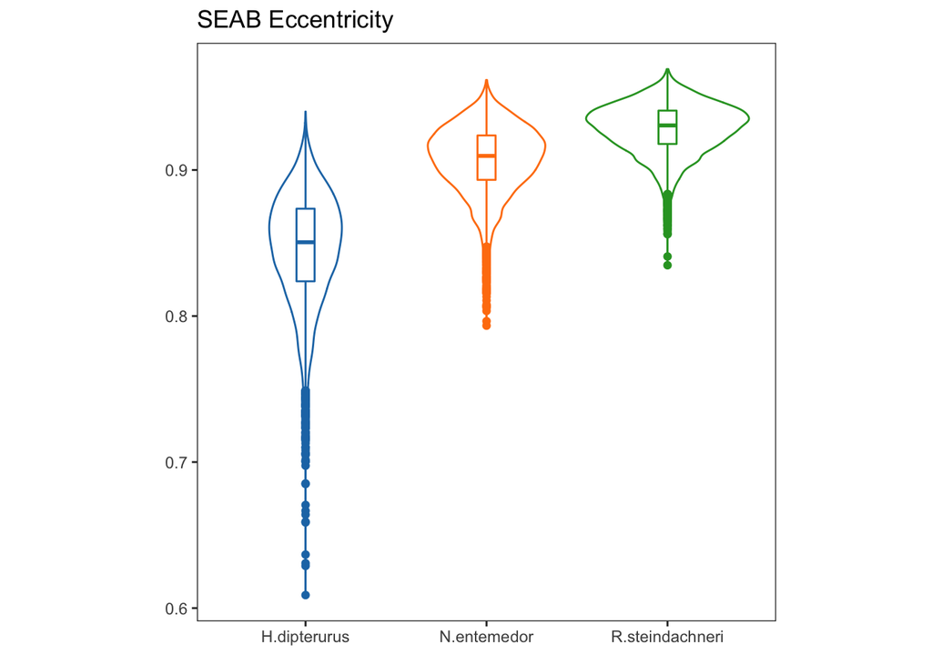

```r
ggplot(data = ecc, aes(x = sp, y = ecc, group = sp, color = factor(sp))) +
  geom_violin(fill = NA, show.legend = F) +
  geom_point(aes(x = sp, y = mean), data = ec, show.legend = F) +
  #geom_errorbar(aes(x = sp, ymin = IQ.lower, ymax = IQ.upper, group = sp), data = ag) +
  geom_boxplot(width = 0.1, show.legend = F) +
  theme_bw() +
  labs(title = "SEAB Eccentricity",
       x = element_blank(),
       y = element_blank()) +
  scale_color_manual(values = global_colors) +
  theme(aspect.ratio = 1,
                       panel.grid.major = element_blank(),
                       panel.grid.minor = element_blank(),
                       legend.position = c(0.15, 0.1),
                       legend.background = element_blank())
```

Theta, on the other hand, is the angle of the semi-major axis of the SEA and the x axis; *i.e.*, the angle of the deformation. Values close to 0 show a higher dispersion in $\delta^{13}C$, while values close to 90 show a higher dispersion in $\delta^{15}N$:

```r
th <- ecc %>% group_by(sp) %>% summarise(IQR.lower = hdi(theta, credMass = 0.5)[1],
                                         IQR.upper = hdi(theta, credMass = 0.5)[2],
                                         hdi.lower = hdi(theta)[1],
                                         hdi.upper = hdi(theta)[2],
                                         mean = mean(theta))
th
```

|  | sp | IQR.lower | IQR.upper | hdi.lower | hdi.upper | mean |
| --- | --- | --- | --- | --- | --- | --- |
| 1 | H.dipterurus | -0.9893953 | -0.8792101 | -1.094133 | -0.7667794 | -0.9316271 |
| 2 | N.entemedor | -1.0461801 | -0.9606210 | -1.128387 | -0.8789242 | -1.0068342 |
| 3 | R.steindachneri | -0.9341685 | -0.8686264 | -1.003648 | -0.8074075 | -0.9022825 |

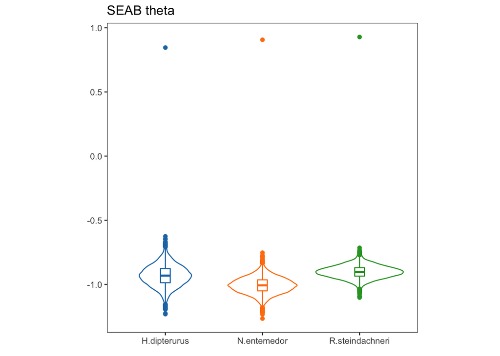

```r
ggplot(data = ecc, aes(x = sp, y = theta, group = sp, color = factor(sp))) +
  geom_violin(fill = NA, show.legend = F) +
  geom_point(aes(x = sp, y = mean), data = ec, show.legend = F) +
  #geom_errorbar(aes(x = sp, ymin = IQ.lower, ymax = IQ.upper, group = sp), data = ag) +
  geom_boxplot(width = 0.1, show.legend = F) +
  theme_bw() +
  labs(title = "SEAB theta",
       x = element_blank(),
       y = element_blank()) +
  scale_color_manual(values = global_colors) +
  theme(aspect.ratio = 1,
                       panel.grid.major = element_blank(),
                       panel.grid.minor = element_blank(),
                       legend.position = c(0.15, 0.1),
                       legend.background = element_blank())
```

## Intra-specific analyses

Basic dataset to extract every case:

```r
full_set <- subset(data, select = c(sp, temporada, sexo, estadio, iso1, iso2))
head(full_set)
```

|  | sp | temporada | sexo | estadio | iso1 | iso2 |
| --- | --- | --- | --- | --- | --- | --- |
| 1 | H.dipterurus | Calida | M | Juvenil | 16.30122 | -14.50678 |
| 2 | H.dipterurus | Calida | H | Juvenil | 16.83237 | -17.81040 |
| 3 | H.dipterurus | Calida | M | Adulto | 17.13546 | -15.83143 |
| 4 | H.dipterurus | Calida | H | Juvenil | 13.12309 | -15.96596 |
| 5 | H.dipterurus | Calida | M | Adulto | 17.63312 | -16.71944 |
| 6 | H.dipterurus | Calida | H | Juvenil | 17.59479 | -16.89169 |

### Custom wrapper around SIBER:

```r
custom_siber <- function(data, var_col, lbls, sp_col, colors, gp_label,
                         n.burnin = 30000, n.iter = 2000){

  subdata <- data[,c(sp_col, var_col, "iso1", "iso2")]
  subdata$group <- factor(subdata[,var_col], labels = seq_along(lbls))
  subdata$community <- 1

  species <- unique(data[, sp_col])

  # Global directory for the variable
  wd <- paste(getwd(), "/", var_col, sep = "")

  # If the directory does not exist, create it:
  if (dir.exists(wd) == F) {dir.create(wd)}

  # Empty lists to store the results:
  siber_objs <- list()
  ellipses <- list()

  summaries <- list()
  autocorr_plots <- list()

  sea_b <- list()
  sea_bt <- data.frame()
  hdis <- data.frame()
  ecc <- data.frame()

  # Posterior differences
  # Define the comparisons
  comps <- expand.grid(a = unique(as.integer(subdata$group)),
                       b = unique(as.integer(subdata$group)))

  comps <- comps[(comps$a != comps$b & comps$b > comps$a), ]
  comps <- comps[order(comps$a),]

  # Put the results in different objects:
  diffs <- data.frame()
  diff_glob <- data.frame()
  p_sup <- data.frame()

  # List with MCMC parameters:
  parms <- list()
    parms <- list()
    parms$n.iter   <- n.iter
    parms$n.burnin <- n.burnin
    parms$n.thin   <- 1
    parms$n.chains <- 3
    parms$save.output <- TRUE

  # List with prior parameters:
  priors <- list()
    priors$R <- 1 * diag(2)
    priors$k <- 2
    priors$tau.mu <- 1.0E-3


  # Basic ellipses plot
  ellipses <- ggplot(data = subdata, aes(x = iso2, y = iso1, color = as.factor(group))) +
                     geom_point(alpha = 0.7) +
                     stat_ellipse(level = 0.4) +
                     geom_convexhull(fill = NA, linetype = "dashed", alpha = 0.05) +
                     scale_color_manual(values = global_colors, name = gp_label, labels = lbls) +
                     scale_x_continuous(limits = xlims, breaks = c(seq(-18, -8, 2))) +
                     scale_y_continuous(limits = ylims, breaks = c(seq(10, 20, 2))) +
                     labs(title = element_blank(),
                          x = expression({delta}^13*C~'(\u2030)'),
                          y = expression({delta}^15*N~'(\u2030)')) +
                     theme_bw() +
                     theme(aspect.ratio = 1,
                           panel.grid.major = element_blank(),
                           panel.grid.minor = element_blank(),
                           #legend.position = c(0.2, 0.15),
                           legend.background = element_blank()) +
                     facet_wrap(paste("~", sp_col, sep = ""))

  cairo_pdf(paste(wd, "ellipses.pdf", sep = "/"), family = "Times", height = 4, width = 8)
    print(ellipses)
  dev.off()

  # Loop through species:
    for (i in seq_along(species)) {

      # Output directory:
      gpwd <- paste(wd, "/", species[i], sep = "")
      if (dir.exists(gpwd) == F) {dir.create(gpwd)}
      parms$save.dir <- gpwd

      # SIBER objects
      siber_objs[[species[i]]] <- createSiberObject(subdata[subdata[, sp_col] == species[i],3:6])

      # Fitting the Bayesian models:
      ellipses[[species[i]]] <- siberMVN(siber_objs[[i]], parms, priors)

      # Diagnostics
      ## Get all the files in the directory
      all_files <- dir(parms$save.dir, full.names = T)
      model_files <- all_files[grep("jags_output", all_files)]

      # Empty lists to store the results
      summaries[[species[i]]] <- list()
      autocorr_plots[[species[i]]] <- list()

      # For each model:
      for (j in seq_along(model_files)) {
        # Load the model output
        load(model_files[j])
        # Create a list with the output
        mcmc_list <- coda::as.mcmc(do.call("cbind", output))

        # Store the summary for each model
        summaries[[species[i]]][[j]]<- MCMCsummary(output,
                                                   params = "all",
                                                   probs = c(0.025, 0.975),
                                                   round = 3)
        # Write the summary to a csv file
        write.csv(summaries[[species[i]]][[j]],
                  paste(gpwd, sprintf("summary_%s.csv",
                                      lbls[j]), sep = "/"),
                  row.names = T)

        # Plot the trace in a pdf
        MCMCtrace(output,
                  params = "all",
                  iter = parms$n.iter,
                  Rhat = T,
                  n.eff = T,
                  ind = T,
                  type = "density",
                  open_pdf = F,
                  #filename = paste(gpwd, sprintf("/MCMCtrace_%d", j), sep = ""))
                  filename = sprintf("MCMCtrace_%s", lbls[j]),
                  wd = gpwd)

        # Store the autocorrelation plots
        autocorr_plots[[species[i]]][[j]] <- mcmc_acf(ellipses[[species[i]]][j]) + labs(title = lbls[j])


      } # End of models loop

      # Autocorrelation plots for every model for every species
      cairo_pdf(paste(gpwd, "/autocorr.pdf", sep = ""), family = "Times")
        gridExtra::grid.arrange(grobs = autocorr_plots[[species[i]]], nrow = 2)
      dev.off()

      # Generation of the ellipses
      sea_b[[species[i]]] <- siberEllipses(ellipses[[species[i]]])

      # Fill the data.frame with the SEAb data
      sea_bt <- rbind(sea_bt,
                      cbind(reshape2::melt(as.data.frame(sea_b[[species[i]]])),
                            sp_col = species[i]))
      if (i == max(seq_along(species))) {colnames(sea_bt) <- c(var_col, "SEAb", sp_col)}


      # Create a data.frame to store the hdis
      # Calculate posterior means
      means <- t(as.data.frame(t(apply(sea_b[[species[i]]], 2, FUN = mean))))
      # Calculate hdis
      hdi <- rbind(as.data.frame(t(apply(sea_b[[species[i]]], 2, FUN = HDInterval::hdi))))
      # Put the results in a data.frame
      temp <- data.frame(hdi, means, sp = species[i])

      # Fill the data.frame with the results
      hdis <- rbind(hdis, temp)

      if (i == max(seq_along(species))) {hdis[var_col] <- paste("V", rep(seq_along(model_files)), sep = "")}

      # Compute the posterior SEAb differences
      for (k in seq_along(comps$a)) {
        a <- comps$a[k]
        b <- comps$b[k]
        comp <- paste(lbls[a], "-", lbls[b])
        diff <- sea_b[[species[i]]][, a] - sea_b[[species[i]]][, b]
        sup <- subset(diff, diff>0, select = diff)

        diffs <- rbind(diffs,
                       data.frame(comp = comp,
                                  diff = diff,
                                  sp = species[i]))
        diff_glob <- rbind(diff_glob,
                           data.frame(comp = comp,
                                      mean = mean(diff),
                                      IQr = t(HDInterval::hdi(diff, credMass = 0.5)),
                                      hdi = t(HDInterval::hdi(diff, credMass = 0.95)),
                                      sp = species[i]
                                      )
                           )
        p_sup <- rbind(p_sup,
                       data.frame(comp = comp,
                                  p_sup = (length(sup)/length(diff))*100,
                                  sp = species[i]))
    }

    diff_glob$comp <- factor(diff_glob$comp, ordered = T)

    }# End of species loop

    # Violin plot of SEAb
    seab <- ggplot() +
              geom_violin(data = sea_bt, aes_string(x = var_col, y = "SEAb", fill = var_col, color = var_col),
                          show.legend = F, alpha = 0.3) +
              geom_boxplot(data = sea_bt,
                           aes_string(x = var_col, y = "SEAb", fill = var_col, color = var_col),
                           alpha = 0.5, width = 0.05, notch = T, show.legend = F,
                           outlier.shape = NA, coef = 0) +
              scale_fill_manual(values = global_colors) +
              scale_color_manual(values = global_colors) +
              # geom_linerange(data = hdi,
              #                aes_string(x = var_col, ymin = "lower", ymax = "upper", color = var_col),
              #                show.legend = F) + # Fix needed
              theme_bw() +
              theme(aspect.ratio = 1,
                    panel.grid.major = element_blank(),
                    panel.grid.minor = element_blank(),
                    legend.position = c(0.2, 0.15),
                    legend.background = element_blank()) +
              labs(x = gp_label,
                   y = expression("SEAb " ('\u2030' ^2) )) +
              scale_x_discrete(labels = lbls) +
              facet_wrap(paste(".~", sp_col, sep = ""), ncol = 3, scales = "free_y")

      cairo_pdf(paste(wd, "SEAb.pdf", sep = "/"), family = "Times", height = 4, width = 8)
        print(seab)
      dev.off()

    print("All models have been run. Check your working directory for the results")
    return(list(summaries = summaries,
                sea_b = sea_b,
                sea_bt = sea_bt,
                hdis = hdis,
                diffs = diffs,
                diff_glob = diff_glob,
                p_sup = p_sup,
                ellips = ellipses))
}
```

### Sex

```r
lbls <- c("Female", "Male")
sex_siber <- custom_siber(full_set, var_col = "sexo", lbls, sp_col = "sp", n.burnin = 7000,
                          colors = global_colors, gp_label = "Sex")
```

```
## [1] "All models have been run. Check your working directory for the results"
```

Eccentricities:

```r
ecc <- data.frame()
for (sp in seq_along(species)) {
  for (j in seq_along(lbls)) {
    ecc <- rbind(ecc,
               data.frame(sp = species[sp],
                          j = lbls[j],
                          ecc = apply(sex_siber$ellips[[species[sp]]][[j]][,1:4], 1, mat_ecc),
                          theta = apply(sex_siber$ellips[[species[sp]]][[j]][,1:4], 1, mat_theta)))

  }
}
```

```r
ec <- ecc %>% group_by(sp, j) %>% summarise(IQR.lower = hdi(ecc, credMass = 0.5)[1],
                                            IQR.upper = hdi(ecc, credMass = 0.5)[2],
                                            hdi.lower = hdi(ecc)[1],
                                            hdi.upper = hdi(ecc)[2],
                                            mean = mean(ecc))
ec
```

| sp | j | IQR.lower | IQR.upper | hdi.lower | hdi.upper | mean |
| --- | --- | --- | --- | --- | --- | --- |
| H.dipterurus | Female | 0.7995188 | 0.8795432 | 0.6705211 | 0.9289872 | 0.8109838 |
| H.dipterurus | Male | 0.8448639 | 0.9005072 | 0.7592489 | 0.9344570 | 0.8547132 |
| N.entemedor | Female | 0.8843590 | 0.9221213 | 0.8325549 | 0.9482729 | 0.8924928 |
| N.entemedor | Male | 0.9298783 | 0.9699906 | 0.8467615 | 0.9879162 | 0.9288437 |
| R.steindachneri | Female | 0.9089081 | 0.9474395 | 0.8420310 | 0.9657115 | 0.9109716 |
| R.steindachneri | Male | 0.9325355 | 0.9565680 | 0.8974510 | 0.9728688 | 0.9376425 |

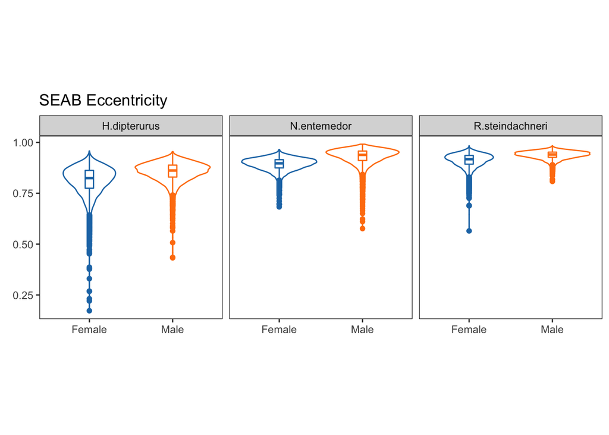

```r
ggplot(data = ecc, aes(x = j, y = ecc, group = j, color = factor(j))) +
  geom_violin(fill = NA, show.legend = F) +
  #geom_point(aes(x = sp, y = mean), data = ag, show.legend = F) +
  #geom_errorbar(aes(x = sp, ymin = IQ.lower, ymax = IQ.upper, group = sp), data = ag) +
  geom_boxplot(width = 0.1, show.legend = F) +
  theme_bw() +
  labs(title = "SEAB Eccentricity",
       x = element_blank(),
       y = element_blank()) +
  scale_color_manual(values = global_colors) +
  theme(aspect.ratio = 1,
                       panel.grid.major = element_blank(),
                       panel.grid.minor = element_blank(),
                       legend.position = c(0.15, 0.1),
                       legend.background = element_blank()) +
  facet_wrap(~sp)
```

Theta:

```r
th <- ecc %>% group_by(sp, j) %>% summarise(IQR.lower = hdi(theta, credMass = 0.5)[1],
                                            IQR.upper = hdi(theta, credMass = 0.5)[2],
                                            hdi.lower = hdi(theta)[1],
                                            hdi.upper = hdi(theta)[2],
                                            mean = mean(theta))
th
```

| sp | j | IQR.lower | IQR.upper | hdi.lower | hdi.upper | mean |
| --- | --- | --- | --- | --- | --- | --- |
| H.dipterurus | Female | -1.0873518 | -0.8908010 | -1.2855256 | -0.6687361 | -0.9728321 |
| H.dipterurus | Male | -0.9733482 | -0.8294806 | -1.1261135 | -0.6848707 | -0.9063583 |
| N.entemedor | Female | -1.0265121 | -0.9256011 | -1.1233848 | -0.8218781 | -0.9763749 |
| N.entemedor | Male | -1.1614691 | -1.0123124 | -1.3202511 | -0.8415647 | -1.0821544 |
| R.steindachneri | Female | -1.0909183 | -0.9721794 | -1.2159753 | -0.8541425 | -1.0399358 |
| R.steindachneri | Male | -0.8747298 | -0.7949961 | -0.9638295 | -0.7269348 | -0.8384022 |

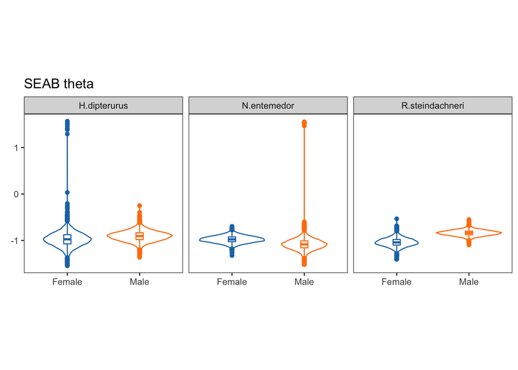

```r
ggplot(data = ecc, aes(x = j, y = theta, group = j, color = factor(j))) +
  geom_violin(fill = NA, show.legend = F) +
  #geom_point(aes(x = sp, y = mean), data = ag, show.legend = F) +
  #geom_errorbar(aes(x = sp, ymin = IQ.lower, ymax = IQ.upper, group = sp), data = ag) +
  geom_boxplot(width = 0.1, show.legend = F) +
  theme_bw() +
  labs(title = "SEAB theta",
       x = element_blank(),
       y = element_blank()) +
  scale_color_manual(values = global_colors) +
  theme(aspect.ratio = 1,
                       panel.grid.major = element_blank(),
                       panel.grid.minor = element_blank(),
                       legend.position = c(0.15, 0.1),
                       legend.background = element_blank()) +
  facet_wrap(~sp)
```

### Age

```r
lbls <- c("Adult", "Juvenile")
age_siber <- custom_siber(full_set, var_col = "estadio", lbls, sp_col = "sp", n.burnin = 7000,
                          colors = global_colors, gp_label = "Age")
```

```
## [1] "All models have been run. Check your working directory for the results"
```

Eccenctricities:

```r
ecc <- data.frame()
for (sp in seq_along(species)) {
  for (j in seq_along(lbls)) {
    ecc <- rbind(ecc,
               data.frame(sp = species[sp],
                          j = lbls[j],
                          ecc = apply(age_siber$ellips[[species[sp]]][[j]][,1:4], 1, mat_ecc),
                          theta = apply(age_siber$ellips[[species[sp]]][[j]][,1:4], 1, mat_theta)))
  }
}
```

```r
ec <- ecc %>% group_by(sp, j) %>% summarise(IQR.lower = hdi(ecc, credMass = 0.5)[1],
                                            IQR.upper = hdi(ecc, credMass = 0.5)[2],
                                            hdi.lower = hdi(ecc)[1],
                                            hdi.upper = hdi(ecc)[2],
                                            mean = mean(ecc))
ec
```

| sp | j | IQR.lower | IQR.upper | hdi.lower | hdi.upper | mean |
| --- | --- | --- | --- | --- | --- | --- |
| H.dipterurus | Adult | 0.8294609 | 0.8906967 | 0.7280329 | 0.9311469 | 0.8381923 |
| H.dipterurus | Juvenile | 0.8241238 | 0.8947843 | 0.7069036 | 0.9361797 | 0.8313793 |
| N.entemedor | Adult | 0.8965375 | 0.9298001 | 0.8488404 | 0.9525541 | 0.9040688 |
| N.entemedor | Juvenile | 0.9350967 | 0.9723756 | 0.8610174 | 0.9896413 | 0.9347803 |
| R.steindachneri | Adult | 0.9290870 | 0.9523896 | 0.9012256 | 0.9719211 | 0.9370932 |
| R.steindachneri | Juvenile | 0.9216891 | 0.9563935 | 0.8586877 | 0.9751430 | 0.9243303 |

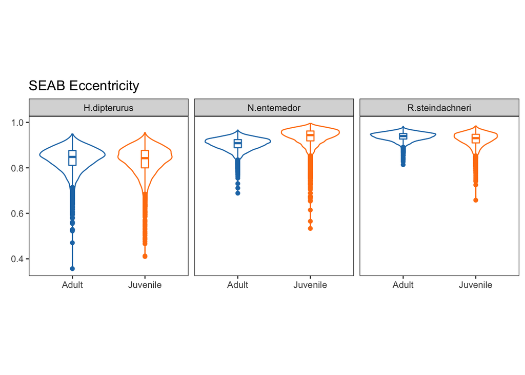

```r
ggplot(data = ecc, aes(x = j, y = ecc, group = j, color = factor(j))) +
  geom_violin(fill = NA, show.legend = F) +
  #geom_point(aes(x = sp, y = mean), data = ag, show.legend = F) +
  #geom_errorbar(aes(x = sp, ymin = IQ.lower, ymax = IQ.upper, group = sp), data = ag) +
  geom_boxplot(width = 0.1, show.legend = F) +
  theme_bw() +
  labs(title = "SEAB Eccentricity",
       x = element_blank(),
       y = element_blank()) +
  scale_color_manual(values = global_colors) +
  theme(aspect.ratio = 1,
                       panel.grid.major = element_blank(),
                       panel.grid.minor = element_blank(),
                       legend.position = c(0.15, 0.1),
                       legend.background = element_blank()) +
  facet_wrap(~sp)
```

Theta:

```r
th <- ecc %>% group_by(sp, j) %>% summarise(IQR.lower = hdi(theta, credMass = 0.5)[1],
                                            IQR.upper = hdi(theta, credMass = 0.5)[2],
                                            hdi.lower = hdi(theta)[1],
                                            hdi.upper = hdi(theta)[2],
                                            mean = mean(theta))
th
```

| sp | j | IQR.lower | IQR.upper | hdi.lower | hdi.upper | mean |
| --- | --- | --- | --- | --- | --- | --- |
| H.dipterurus | Adult | -1.0354011 | -0.8842245 | -1.194902 | -0.7268824 | -0.9576144 |
| H.dipterurus | Juvenile | -1.0832629 | -0.9061837 | -1.246265 | -0.6913947 | -0.9789916 |
| N.entemedor | Adult | -1.1430933 | -1.0490065 | -1.239654 | -0.9618981 | -1.1014211 |
| N.entemedor | Juvenile | -1.0075255 | -0.8670483 | -1.150970 | -0.7086468 | -0.9346158 |
| R.steindachneri | Adult | -0.9383186 | -0.8611529 | -1.021657 | -0.7951578 | -0.9071159 |
| R.steindachneri | Juvenile | -0.8855256 | -0.7718555 | -1.012924 | -0.6616609 | -0.8337463 |

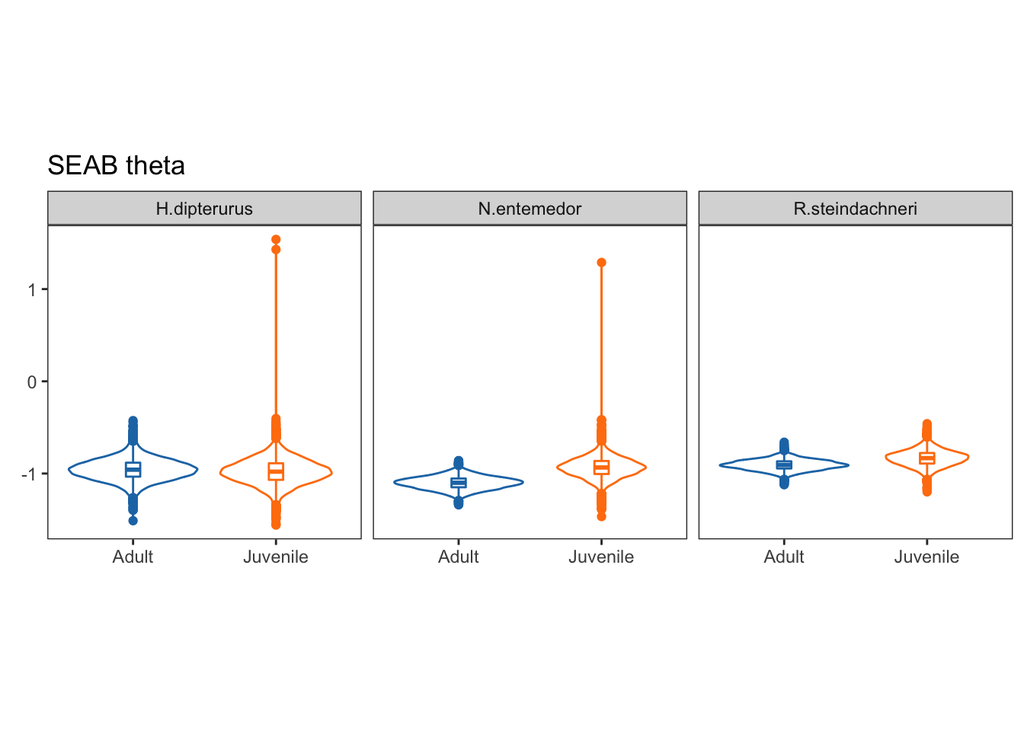

```r
ggplot(data = ecc, aes(x = j, y = theta, group = j, color = factor(j))) +
  geom_violin(fill = NA, show.legend = F) +
  #geom_point(aes(x = sp, y = mean), data = ag, show.legend = F) +
  #geom_errorbar(aes(x = sp, ymin = IQ.lower, ymax = IQ.upper, group = sp), data = ag) +
  geom_boxplot(width = 0.1, show.legend = F) +
  theme_bw() +
  labs(title = "SEAB theta",
       x = element_blank(),
       y = element_blank()) +
  scale_color_manual(values = global_colors) +
  theme(aspect.ratio = 1,
                       panel.grid.major = element_blank(),
                       panel.grid.minor = element_blank(),
                       legend.position = c(0.15, 0.1),
                       legend.background = element_blank()) +
  facet_wrap(~sp)
```

### Season

```r
lbls <- c("Warm", "Cold")
season_siber <- custom_siber(full_set, var_col = "temporada", lbls, sp_col = "sp",
                             colors = global_colors, gp_label = "Season",
                             n.burnin = 750000, n.iter = 10000)
```

```
## Too few points to calculate an ellipse
```

```
## [1] "All models have been run. Check your working directory for the results"
```

```r
ecc <- data.frame()
for (sp in seq_along(species)) {
  for (j in seq_along(lbls)) {
    ecc <- rbind(ecc,
               data.frame(sp = species[sp],
                          j = lbls[j],
                          ecc = apply(season_siber$ellips[[species[sp]]][[j]][,1:4], 1, mat_ecc),
                          theta = apply(season_siber$ellips[[species[sp]]][[j]][,1:4], 1, mat_theta)))
  }
}
```

```r
ec <- ecc %>% group_by(sp, j) %>% summarise(IQR.lower = hdi(ecc, credMass = 0.5)[1],
                                            IQR.upper = hdi(ecc, credMass = 0.5)[2],
                                            hdi.lower = hdi(ecc)[1],
                                            hdi.upper = hdi(ecc)[2],
                                            mean = mean(ecc))
ec
```

| sp | j | IQR.lower | IQR.upper | hdi.lower | hdi.upper | mean |
| --- | --- | --- | --- | --- | --- | --- |
| H.dipterurus | Cold | 0.7660787 | 0.8890873 | 0.5326671 | 0.9473351 | 0.7714303 |
| H.dipterurus | Warm | 0.8336521 | 0.8857966 | 0.7566386 | 0.9195491 | 0.8450390 |
| N.entemedor | Cold | 0.9126847 | 0.9409878 | 0.8727236 | 0.9596135 | 0.9191660 |
| N.entemedor | Warm | 0.7922976 | 0.9126001 | 0.5438435 | 0.9602459 | 0.7866460 |
| R.steindachneri | Cold | 0.9490011 | 0.9980587 | 0.7297726 | 0.9999228 | 0.9188269 |
| R.steindachneri | Warm | 0.9231175 | 0.9455566 | 0.8907845 | 0.9593474 | 0.9283355 |

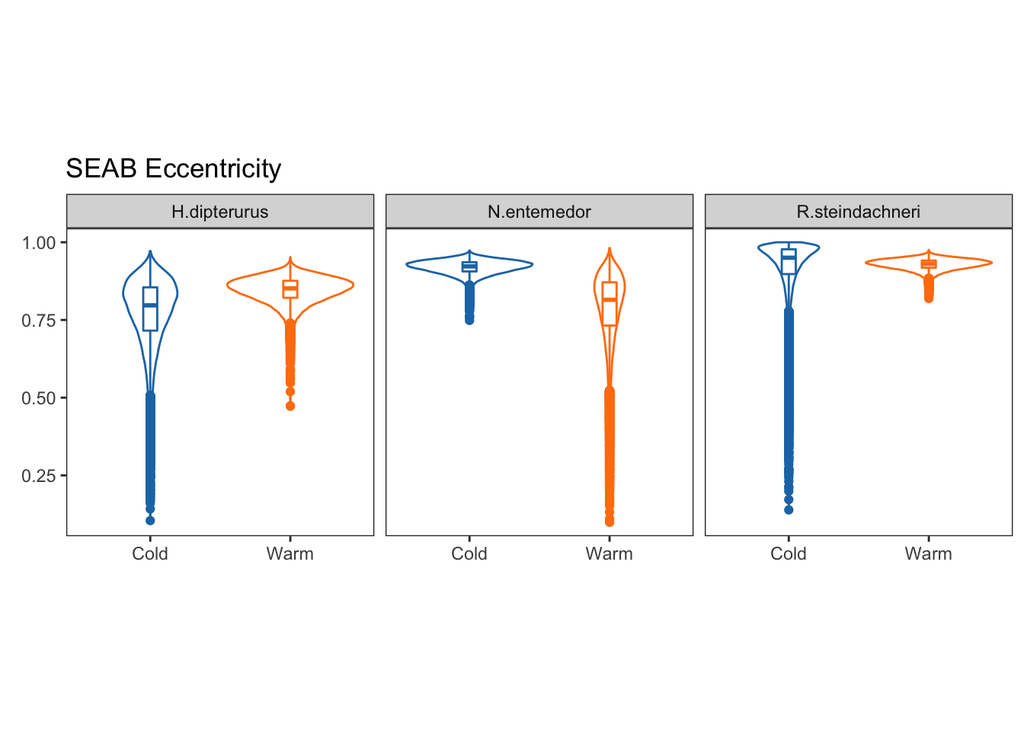

```r
ggplot(data = ecc, aes(x = j, y = ecc, group = j, color = factor(j))) +
  geom_violin(fill = NA, show.legend = F) +
  #geom_point(aes(x = sp, y = mean), data = ag, show.legend = F) +
  #geom_errorbar(aes(x = sp, ymin = IQ.lower, ymax = IQ.upper, group = sp), data = ag) +
  geom_boxplot(width = 0.1, show.legend = F) +
  theme_bw() +
  labs(title = "SEAB Eccentricity",
       x = element_blank(),
       y = element_blank()) +
  scale_color_manual(values = global_colors) +
  theme(aspect.ratio = 1,
                       panel.grid.major = element_blank(),
                       panel.grid.minor = element_blank(),
                       legend.position = c(0.15, 0.1),
                       legend.background = element_blank()) +
  facet_wrap(~sp)
```

Theta:

```r
th <- ecc %>% group_by(sp, j) %>% summarise(IQR.lower = hdi(theta, credMass = 0.5)[1],
                                            IQR.upper = hdi(theta, credMass = 0.5)[2],
                                            hdi.lower = hdi(theta)[1],
                                            hdi.upper = hdi(theta)[2],
                                            mean = mean(theta))
th
```

| sp | j | IQR.lower | IQR.upper | hdi.lower | hdi.upper | mean |
| --- | --- | --- | --- | --- | --- | --- |
| H.dipterurus | Cold | -1.208323 | -0.8578777 | -1.570760 | -0.0167624 | -0.8990872 |
| H.dipterurus | Warm | -1.066494 | -0.9405742 | -1.190093 | -0.8112275 | -1.0009335 |
| N.entemedor | Cold | -1.078602 | -0.9938995 | -1.161195 | -0.9098395 | -1.0329483 |
| N.entemedor | Warm | -1.143253 | -0.7865510 | -1.570118 | -0.1474675 | -0.8572931 |
| R.steindachneri | Cold | -0.669867 | -0.3264093 | -1.249658 | 0.3017363 | -0.4460995 |
| R.steindachneri | Warm | -0.961750 | -0.8925522 | -1.029303 | -0.8253612 | -0.9266550 |

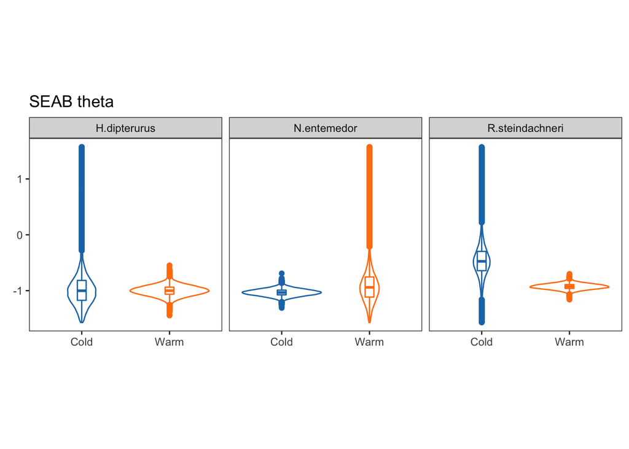

```r
ggplot(data = ecc, aes(x = j, y = theta, group = j, color = factor(j))) +
  geom_violin(fill = NA, show.legend = F) +
  #geom_point(aes(x = sp, y = mean), data = ag, show.legend = F) +
  #geom_errorbar(aes(x = sp, ymin = IQ.lower, ymax = IQ.upper, group = sp), data = ag) +
  geom_boxplot(width = 0.1, show.legend = F) +
  theme_bw() +
  labs(title = "SEAB theta",
       x = element_blank(),
       y = element_blank()) +
  scale_color_manual(values = global_colors) +
  theme(aspect.ratio = 1,
                       panel.grid.major = element_blank(),
                       panel.grid.minor = element_blank(),
                       legend.position = c(0.15, 0.1),
                       legend.background = element_blank()) +
  facet_wrap(~sp)
```

### Final forestplot:

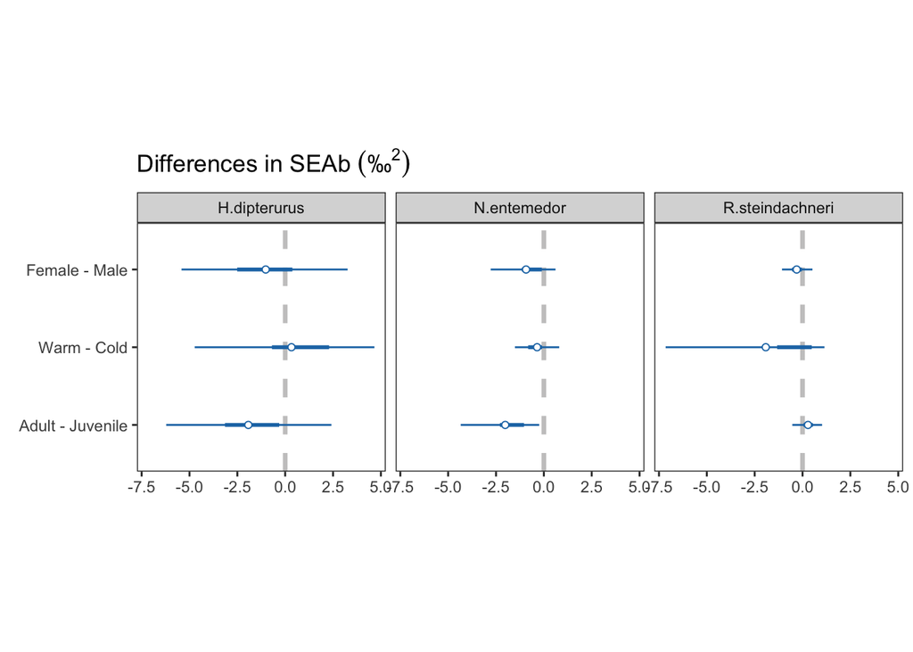

```r
forest_data <- rbind(age_siber[[6]], season_siber[[6]], sex_siber[[6]])

forest <- ggplot(data = forest_data) +
               geom_vline(xintercept = 0, linetype = "dashed", color = "#C9C8C8", size = 1.2) +
               geom_linerange(aes(y = comp, xmin = IQr.lower, xmax = IQr.upper),
                              color = global_colors[1], size = 1) +
               geom_linerange(aes(y = comp, xmin = hdi.lower, xmax = hdi.upper),
                              color = global_colors[1]) +
               geom_point(aes(x = mean, y = comp), color = global_colors[1], fill = "white", size = 1.5, shape = 21) +
               theme_bw() +
               theme(aspect.ratio = 1,
                     panel.grid.major = element_blank(),
                     panel.grid.minor = element_blank(),
                     legend.position = c(0.2, 0.15),
                     legend.background = element_blank()) +
               labs(title = expression("Differences in SEAb " ('\u2030' ^2) ),
                    x = element_blank(),
                    y = element_blank()) + facet_wrap(~sp)

#cairo_pdf("forest_cats.pdf", family = "Times", width = 8, height = 4)
forest
```

```r
#dev.off()
```

```r
season_siber$p_sup
```

| comp | p_sup | sp |
| --- | --- | --- |
| Warm - Cold | 59.53000 | H.dipterurus |
| Warm - Cold | 24.37333 | N.entemedor |
| Warm - Cold | 19.05667 | R.steindachneri |

```r
sex_siber$p_sup
```

| comp | p_sup | sp |
| --- | --- | --- |
| Female - Male | 31.93333 | H.dipterurus |
| Female - Male | 11.96667 | N.entemedor |
| Female - Male | 21.20000 | R.steindachneri |

```r
age_siber$p_sup
```

| comp | p_sup | sp |
| --- | --- | --- |
| Adult - Juvenile | 18.81667 | H.dipterurus |
| Adult - Juvenile | 0.35000 | N.entemedor |
| Adult - Juvenile | 78.55000 | R.steindachneri |